# Hospitalizations for psychiatric conditions among adolescents during the COVID-19 pandemic

```r
# Install packages
paket <- function(pak){
  new_pak <- pak[!(pak %in% rownames(installed.packages()))]
  if (length(new_pak))
    install.packages(new_pak, dependencies = TRUE,repos="https://cloud.r-project.org/")
  sapply(pak, library, character.only = TRUE)
}

listOfPackages <- c("tidyverse", "RColorBrewer", "knitr", "kableExtra", "tsModel")
paket(listOfPackages)
```

```r
# options(repr.plot.width = 18, repr.plot.height = 9)
theme_plots <- theme_bw() +
  theme(strip.text = element_text(size = 5),
        axis.text.x = element_text(size = 8),
        axis.text.y = element_text(size = 6),
        axis.title.x = element_text(size = 8),
        axis.title.y = element_text(size = 8),
        title = element_text(size = 10),
        plot.subtitle = element_text(size = 9, face = "italic"))
theme_set(theme_plots)

# Colorblind palette
cbPalette <- c("#999999", "#E69F00", "#56B4E9", "#009E73", "#F0E442", "#0072B2", "#D55E00", "#CC79A7")
```

# Inclusion criteria

# Variables that need to be checked/modified by each site

Change the values of the following variables according to the specificities of your site: - “folder_4ce_files”: folder path where your phase 2.2 data files are located - “obfuscation”: determine the obfuscation threshold (FALSE if no obfuscation, or the numeric value of the obfuscation threshold if any) - “raceAvailable”: set as TRUE or FALSE depending on whether the variable is being collected at your site - “dateFormat”: specify the format of the date at your site (e.g., for “03-AUG-20”, the format would be “%d-%b-%y”, [see documentation](https://www.stat.berkeley.edu/~s133/dates.html))

```r
folder_4ce_files <- "/Input/09212021_2/"
obfuscation =  FALSE
#obfuscation = 3
raceAvailable = TRUE
#raceAvailable = FALSE
dateFormat <- "%d-%b-%y"
min_hosp_days <- 2
```

```r
# cut-off dates used in the analysis, these should not be changed
history_start_date <- "2019-01-01"
history_end_date <- "2021-05-31"
pandemic_start_date <- "2020-03-15"
```

# Data input

We will use as input the 2.2 data files. Specifically: - LocalPatientSummary - LocalPatientObservation - LocalPatientClinicalcourse

For sites recording the race, we will also use an additional file: - LocalPatientRace

## Read csv files

### 4CE phase 2.2 files

```r
### Read the CSV input files
source("R/readInputFiles.R")


files <- readInputFiles( path      = "../Input/09212021_2/",
                         separator = ",",
                         skip      = 0,
                         verbose   = FALSE )

## Create the output folder if it doesn't exist
#if (! "output" %in% list.dirs()) dir.create("output")

### Extract the patient summary and observation information.
demo_raw <- files[["patientSummary"]]
obs_raw <- files[["patientObservations"]]
clinical_raw <- files[["patientClinicalCourse"]]

### Read the file containing race information for those sites recording this variable
if( raceAvailable == TRUE ){
  race_raw <- read.delim(paste0("../", folder_4ce_files, "/LocalPatientRace.csv"), sep = ",", skip = 0)
}
```

```r
# Adding filtering on in_hospital == 1 here to reduce subsequent compute time
clinical_raw <- filter(clinical_raw, in_hospital == 1)
```

### Adding columns with hospitalization number and hospitalization length to the clinical raw file

```r
count_sequences_hospitalisation <- function(df, ...) {
  seq_hospitalisation_df <- data.frame(total_span = seq(min(df$days_since_admission),
                                                        max(df$days_since_admission))
  ) %>%
    left_join(df, by = c("total_span" = "days_since_admission")) %>%
    replace_na(list(in_hospital = 0))
  count_sequences <- rle(seq_hospitalisation_df$in_hospital)
  count_sequences_1 <- lapply(count_sequences, function(x) x[count_sequences$values == 1])
  n_sequences <- seq_along(count_sequences_1$lengths)
  sequences <- rep.int(n_sequences, count_sequences_1$lengths)
  sequences_len <- rep.int(count_sequences_1$lengths, count_sequences_1$lengths)
  stopifnot(length(df$days_since_admission) == length(sequences))
  data.frame(days_since_admission = df$days_since_admission,
             n_hospitalisation = sequences,
             len_hospitalisation = sequences_len)
}
stopifnot(all(clinical_raw$in_hospital == 1))
hospitalisations_seq_df <- clinical_raw %>%
  distinct(patient_num, cohort, days_since_admission, in_hospital) %>%
  group_by(patient_num, cohort) %>%
  group_modify(count_sequences_hospitalisation)

clinical_raw <- left_join(clinical_raw,
                          hospitalisations_seq_df,
                          by = c("patient_num", "cohort", "days_since_admission"))
```

### Read the ICD10 codes file

The file containing the ICD10 psychiatric related codes is located in the `public-data` folder of the GitHub repository.

```r
#icdCodes <- read.csv("public-data/pediatric_psychiatric_ICD10_codes.csv", header = TRUE, colClasses = "character") %>%
#  rename(disorder_group = Mental.Health.Disorder.Group,
#         description = Description,
#         originalCode = ICD10_Code) %>%
#  mutate( ICD10_Code= ifelse( nchar( originalCode) > 3, paste0(substr( originalCode, 1, 3), ".", substr(  originalCode, 4, nchar(originalCode))),originalCode)) %>%
#  select( disorder_group, ICD10_Code, description)

icdCodes <- read.csv("public-data/pediatric_psychiatric_ICD10_codesV2.csv", header = TRUE, colClasses = "character") %>%
   filter( flag %in% c("originalCodes", "FrenchSpecificCodes")) %>%
   select( disorder_group, ICD10_Code, description )
```

## All cohort

```r
# Adjusting patient age at the time of visit, assuming the age used is the patients' age at the time of extraction (last discharge date available in the data)
last_data_date <- max(as.Date(demo_raw$last_discharge_date, "%Y-%m-%d"))
clinical_raw <- left_join(clinical_raw, demo_raw[c("patient_num", "cohort", "age", "sex")], by = c("patient_num", "cohort"))
clinical_raw$age_time_visit <- clinical_raw$age - floor(as.numeric(last_data_date - as.Date(clinical_raw$calendar_date, dateFormat)) / 365.25)
clinical_raw <- select(clinical_raw, -age)

clinical_raw_filter <- clinical_raw %>%
  filter( len_hospitalisation > min_hosp_days) %>%
  dplyr::mutate( date = as.Date( calendar_date, format = dateFormat ),
                 weeks = as.Date(cut( date, breaks = "week")),
                 month = as.Date(cut( date, breaks = "month")),
                 year = format( date, "%Y"),
                 period = ifelse( date < pandemic_start_date,
                                  "before_pandemic","during_pandemic")) %>%
  dplyr::filter(cohort  %in% c("AllAdm"))
```

```r
all_codes <- clinical_raw_filter %>%
  left_join( obs_raw,  by = c("patient_num", "cohort", "days_since_admission")) %>%
  filter( concept_type == 'DIAG-ICD10')
stopifnot(unique(all_codes$in_hospital) == 1)
stopifnot(unique(all_codes$len_hospitalisation > min_hosp_days))
```

## First estimation: total number of patients without filtering by any disease subtype

### New hospitalizations

```r
new_hospitalizations_per_day <- all_codes %>%
  group_by(patient_num, n_hospitalisation) %>% slice(which.min(date)) %>%
  filter( in_hospital == 1,
         date < '2021-05-01' &
         date >= '2019-03-01' ) %>%
    group_by( date, weeks, month) %>%
  summarise(count = n_distinct(patient_num)) %>%
  ungroup()
```

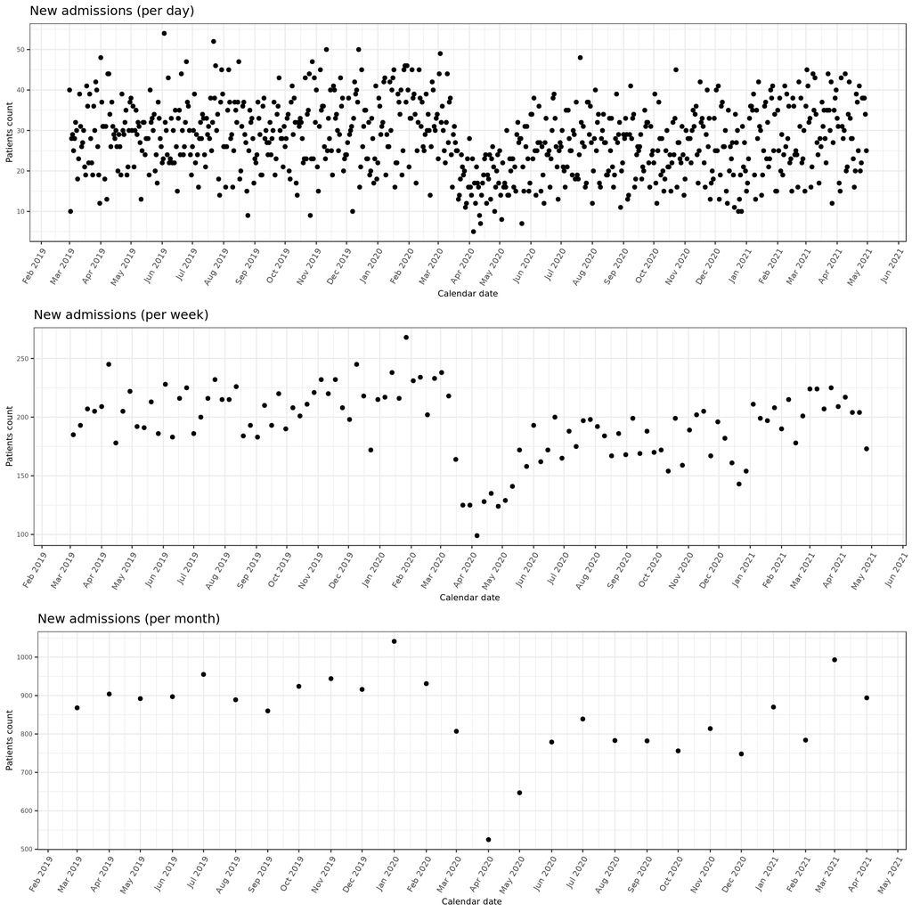

```r
new_hospitalizations_per_week <- new_hospitalizations_per_day %>%
  filter(weeks >= '2019-03-01') %>%
  group_by( weeks) %>%
  summarise(count = sum(count))


new_hospitalizations_per_month <- new_hospitalizations_per_day %>%
  group_by( month) %>%
  summarise(count = sum(count))


nh_day <- ggplot(new_hospitalizations_per_day,
                 aes(x = date, y = count))  +
  geom_point() +
  scale_x_date(date_breaks = "1 month", date_labels =  "%b %Y") +
  theme(axis.text.x=element_text(angle=60, hjust=1))+
  labs(x = "Calendar date",
       y = "Patients count",
       title = "New admissions (per day)")

nh_week <- ggplot(new_hospitalizations_per_week, aes(x = weeks,
                       y = count))  +
  geom_point() +
  scale_x_date(date_breaks = "1 month", date_labels =  "%b %Y") +
  theme(axis.text.x=element_text(angle=60, hjust=1))+
  labs(x = "Calendar date",
       y = "Patients count",
       title = "New admissions (per week)")

nh_month <- ggplot(new_hospitalizations_per_month, aes(x = month,
                       y = count))  +
  geom_point() +
  scale_x_date(date_breaks = "1 month", date_labels =  "%b %Y") +
  theme(axis.text.x=element_text(angle=60, hjust=1))+
  labs(x = "Calendar date",
       y = "Patients count",
       title = "New admissions (per month)")

require(gridExtra)
grid.arrange(nh_day,
             nh_week,
             nh_month,
             ncol=1)
```

### Total hospitalize patients

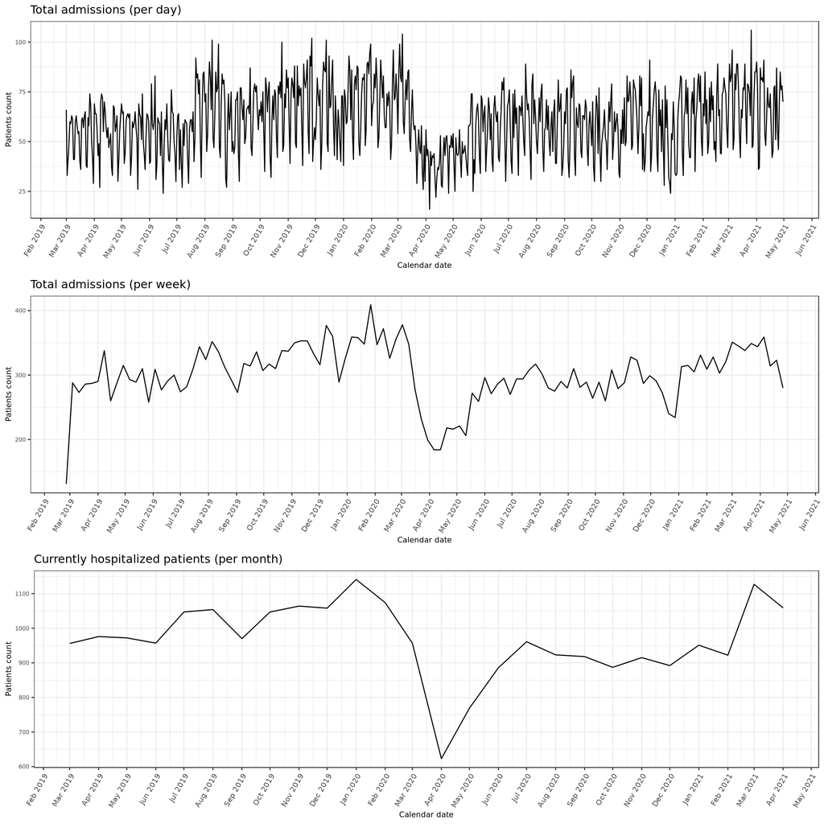

```r
total_hospitalizations_per_day <- all_codes %>%
  filter(date < '2021-05-01' &
         date >= '2019-03-01' ) %>%
    group_by( date ) %>%
  summarise(count = n_distinct(patient_num))

total_hospitalizations_per_week <- all_codes %>%
  filter(date < '2021-05-01' &
         date >= '2019-03-01' ) %>%
    group_by( weeks ) %>%
  summarise(count = n_distinct(patient_num))

total_hospitalizations_per_month <- all_codes %>%
  filter(date < '2021-05-01' &
         date >= '2019-03-01' ) %>%
    group_by( month ) %>%
  summarise(count = n_distinct(patient_num))



th_day <- ggplot(total_hospitalizations_per_day, aes(x = date,
                       y = count))  +
  geom_line() +
  scale_x_date(date_breaks = "1 month", date_labels =  "%b %Y") +
  theme(axis.text.x=element_text(angle=60, hjust=1))+
  labs(x = "Calendar date",
       y = "Patients count",
       title = "Total admissions (per day)")

th_week <- ggplot(total_hospitalizations_per_week, aes(x = weeks,
                       y = count))  +
  geom_line() +
  scale_x_date(date_breaks = "1 month", date_labels =  "%b %Y") +
  theme(axis.text.x=element_text(angle=60, hjust=1))+
  labs(x = "Calendar date",
       y = "Patients count",
       title = "Total admissions (per week)")

th_month <- ggplot(total_hospitalizations_per_month, aes(x = month,
                       y = count))  +
  geom_line() +
  scale_x_date(date_breaks = "1 month", date_labels =  "%b %Y") +
  theme(axis.text.x=element_text(angle=60, hjust=1))+
  labs(x = "Calendar date",
       y = "Patients count",
       title = "Currently hospitalized patients (per month)")

require(gridExtra)
grid.arrange(th_day, th_week, th_month, ncol=1)
```

## Second estimation: total number of patients filtering by psychiatric disorders

## Creating the inputTable

Creation of the inputTable that will be the only table used throughout the rest of the analysis - selecting only visits with at least one ICD codes pertaining to the mental health categories - filter visits where patients are between 11 and 17 years old - add the demographic and hospitalization related information - add the ICD code description and the related disorder group

### Check that we have patients with the ICD10 mental codes

```r
### check that the ICD codes follow the regular expression [A-Z][0-9][0-9AB]\.?[0-9A-TV-Z]{0,4}
codesToReview <- obs_raw %>% dplyr::filter(concept_type == "DIAG-ICD10",
                                           ! grepl( "[A-Z][0-9][0-9AB]\\.?[0-9A-TV-Z]{0,4}", concept_code))
print(codesToReview)
```

```
##   siteid cohort patient_num days_since_admission concept_type concept_code
## 1    BCH AllAdm     1745440                  105   DIAG-ICD10          FDX
##   value
## 1  -999
```

```r
### Calculate how many of the mental codes are in the dataset
mentalHealthCodes <- unique( all_codes %>%
  dplyr::filter( concept_type == "DIAG-ICD10",
                 concept_code %in% icdCodes$ICD10_Code ) %>%
  dplyr::mutate( concept_code = as.character( concept_code ),
                 concept_length = nchar( concept_code ),
                 concept_check = ifelse( concept_length == 4 | concept_length > 8, "Check", "OK")) %>%
  dplyr::select( concept_code, concept_length, concept_check) )

summary(as.factor( mentalHealthCodes$concept_check ) )
```

```
##  OK
## 457
```

```r
print( paste0("There are ", length(mentalHealthCodes$concept_code), " ICD10 mental codes out of the total ",length(unique(icdCodes$ICD10_Code)), " in the dataset"))
```

```
## [1] "There are 457 ICD10 mental codes out of the total 1699 in the dataset"
```

### Add the mental ICD code description and filter

```r
# Getting site name, will be used later in the analysis
site <- unique(as.character(demo_raw$siteid))

icdCategory <- read.delim("public-data/icd10Codes.txt", header = FALSE, colClasses = "character")
colnames(icdCategory) <- c("icd_code_letter", "icd_description_category")

all_codes_desc <- all_codes %>%
    left_join( icdCodes, by=c("concept_code" = "ICD10_Code") ) %>%
  mutate(icd_code_category = ifelse(concept_code %in% icdCodes$ICD10_Code,
                               "psy",
                               "others")) %>%
  dplyr::select( patient_num, cohort, sex, age_time_visit, concept_type, concept_code, calendar_date,
                 in_hospital, n_hospitalisation, len_hospitalisation, date, weeks, month, year,
                 period, disorder_group, description, icd_code_category )

all_codes_desc <- all_codes_desc %>%
  mutate( icd_code_letter = ifelse(substr(concept_code, 1, 1) %in% c("D", "H"), substr(concept_code, 1, 2), substr(concept_code, 1, 1) ))

all_codes_desc <- left_join( all_codes_desc, icdCategory) %>%
  mutate( icd_description_category = replace_na( ifelse( concept_code %in% icdCodes$ICD10_Code, "Psy", icd_description_category), "Others"))

input_data <- all_codes_desc %>%
  filter(concept_code %in% icdCodes$ICD10_Code)

if( raceAvailable == TRUE ){
  input_data <- input_data %>%
    left_join( race_raw, by = c("patient_num", "cohort") )
}
```